# Multivariate analyses and graphics

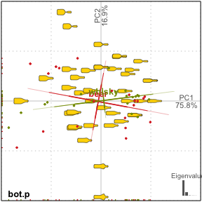

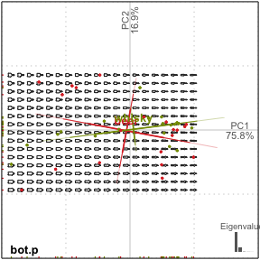

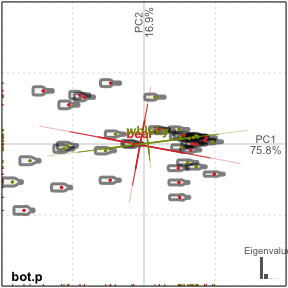

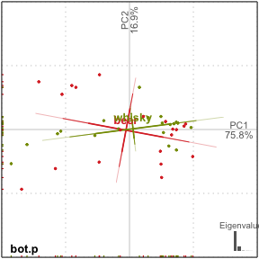

```r
plot(bot.p, 1, pos.shp="circle", nb.shp=16, col.shp="gold")
plot(bot.p, 1, pos.shp="range", nr.shp=20, nc.shp=15,
     size.shp = 1/3, amp.shp=2, border.shp="grey20")
plot(bot.p, 1, pos.shp="xy", lwd.shp=3)
plot(bot.p, 1, morphospace=FALSE) # no morphospace
```

And variations around some kernel density estimates.

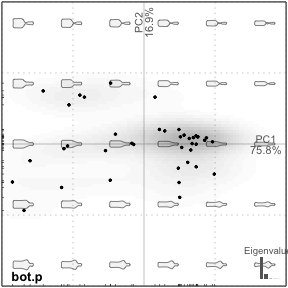

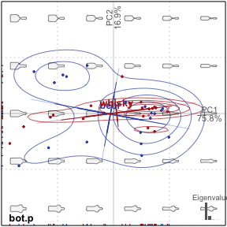

```r
plot(bot.p, density=TRUE, contour=FALSE) # density only
plot(bot.p, 1, contour=TRUE, lev.contour=5, palette=col.autumn) # contour only
```

Here I have used the bottles dataset, but we can used another approach, for instance orthogonal polynomial fitting on open curves. Let’s try on the dataset `olea`.

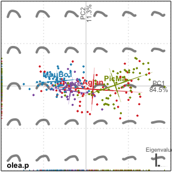

```r
data(olea)
olea.pol <- orthoPolynomials(olea, 5, nb.pts = 60)
olea.p <- PCA(olea.pol)
plot(olea.p, "cep", lwd.shp=2)
```

And reconstructed shapes are also open curves. Let’s try with configuration of landmarks. Note that morphospace still needs to handle landmarks + links properly. Soon.

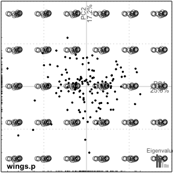

```r
data(wings)
wings.al <- fgProcrustes(wings, verbose=FALSE, tol = 1e-4) # to speed up
wings.p <- PCA(wings.al)
plot(wings.p)
```

In other words, once you are familiar with the (very limited though) grammar of Momocs, you can do all the morphometrics approach and further analyses in a very parallel fashion.

Two more things. You can use the function `plot3` to plot a combination of the three PC axes, and all the options can be passed to it. Try:

```r
plot3(bot.p, 1, contour=TRUE, lev.contour=5,
      pos.shp="circle", border.shp="grey20")
```

Also, `plot.PCA` is pretty generic, so you can easily plot any `pca` output from `prcomp`, or any other function. It just needs a `$x` and a `$fac` components. See the example below.

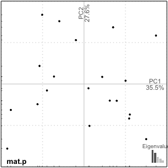

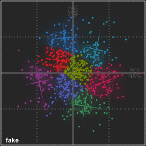

```r
# a pca
mat <- matrix(rnorm(100), 20)
mat.p <- prcomp(mat)
class(mat.p) <- "PCA"
plot(mat.p)

# a kmeans-helped scatter-plot
set.seed(123)
x <- replicate(2, rnorm(500))
fac <- factor(kmeans(x, centers = 8)$cluster)
fake <- list(x=x)
class(fake) <- c("PCA", class(PCA))
op <- par(bg="grey20", fg="white")
plot(fake, fac, density=TRUE, palette=col.solarized, eigen=FALSE)
par(op)
```

# MANOVA: Multivariate analysis of variance

```r
Manova(bot.f, "type") #bottles - type
```

```
##  * 1st harmonic removed (because of normalization)
##  * 'retain' was missing. MANOVA done with 10 harmonics and the first 1 dropped
```

```
##           Df Hotelling-Lawley approx F num Df den Df Pr(>F)
## fac        1              441     36.7     36      3 0.0062 **
## Residuals 38
## ---
## Signif. codes:  0 '***' 0.001 '**' 0.01 '*' 0.05 '.' 0.1 ' ' 1
```

```r
Manova(olea.pol, "cep") #olea - cepages
```

```
##  * Manova done on: Intercept x1 x2 x3 x4 x5
```

```
##            Df Hotelling-Lawley approx F num Df den Df Pr(>F)
## fac         3             1.47     16.3     18    599 <2e-16 ***
## Residuals 206
## ---
## Signif. codes:  0 '***' 0.001 '**' 0.01 '*' 0.05 '.' 0.1 ' ' 1
```

```r
# not yet on Ldk.
```

If you want to test all pairwise differences between levels of a group, try `ManovaPW`:

```r
ManovaPW(olea.pol, "cep")
```

```
## $stars.tab
##        Aglan Cypre MouBo1 PicMa
## Aglan        -     ***    ***
## Cypre              ***    ***
## MouBo1                    ***
##
## $summary (see also $manovas)
##                Df Hotelling-Lawley approx F num Df den Df    Pr(>F)
## Aglan - Cypre   1           0.1601    1.014      6     38 4.309e-01
## Aglan - MouBo1  1           1.0177    8.990      6     53 8.932e-07
## Aglan - PicMa   1           2.5349   22.392      6     53 6.091e-13
## Cypre - MouBo1  1           0.9524    6.032      6     38 1.673e-04
## Cypre - PicMa   1           2.2348   14.154      6     38 2.154e-08
## MouBo1 - PicMa  1           4.1956   37.061      6     53 2.823e-17
```

# LDA: Linear Discriminant Analysis

But some method on `Coe`are available.

```r
bot.l <- LDA(bot.p, "type")
```

```
##  * the first 5 PC axes are used.
```

```r
plot(bot.l)
```

[output not shown]

[figure not shown]

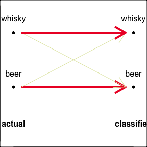

```r
plotCV2(bot.l$CV.tab)
bot.l
```

And on olea:

```r
olea.l <- LDA(olea.p, "cep")
```

```
##  * the first 5 PC axes are used.
```

```
##           actual
## classified PicMa MouBo1 Cypre Aglan
##     Aglan     20      5    12    21
##     Cypre      1      1     5     2
##     MouBo1     2     54    13    16
##     PicMa     37      0     0    21
```

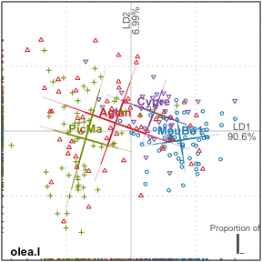

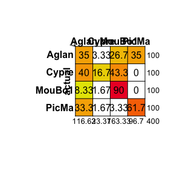

```r
plot(olea.l)
plotCV(olea.l$CV.tab)
```

Note that almost all plotting options for PCA also work for LDA!

# Hierarchical clustering

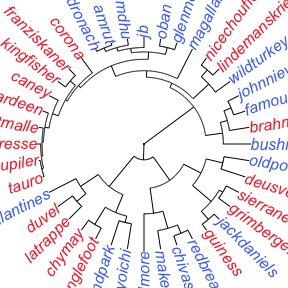

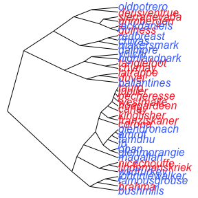

```r
# todo: add shapes on hclust plots
clust(bot.f, "type", type = "fan")
clust(bot.f, "type", type = "cladogram")
```